# Разведочный анализ данных о пользователях TripAdvisor

Alexey Shovkun

Tuesday, April 14, 2015

## Разведка исходных даных

Посмотрим на данные.

```
##                                uid memberName    memberTitle
## 1 813EFCF9A589AA6F946F82BB5FF9619E    smolkin        Эксперт
## 2 1AC301553A4995D3CE2DE923E752969F     Olga F           <NA>
## 3 F72DFA205249975A68620F8234A451AF    Vadstar Старший критик
## 4 F9C407B9C042CA6EF7F7818EC1027D97 Visitor211           <NA>
## 5 BA46856688BB68CED76F5DA164B3EEFA  ol_moscow Старший критик
## 6 4D29748A00F0BAABF599B1DF63D7598D     Andy P        Эксперт
##   registrationYear ageGroup     sex   city country reviews5Count
## 1             2014          мужчина Москва  Россия           946
## 2             2013                  Москва  Россия            NA
## 3             2014                  Москва  Россия             2
## 4             2011                  Москва  Россия            NA
## 5             2011                  Москва  Россия            14
## 6             2014    35-49 мужчина Москва  Россия            16
##   reviews4Count reviews3Count reviews2Count reviews1Count
```

[output cut: 48 more lines]

Таблица с данными содержит столбцы с описательными параметрами, которые являются уникальными для каждого пользователя и не могут влиять на классификацию интересен/не интересен: memberName, urlMessage, url. При решении задачи классификации будем игнорировать эти параметры.

Числовые параметры *Count могут содержать пустые значения (NA), заменим их на 0. Также необходимо нормализовать числовые параметры, приведя их к значениям в диапазоне [0, 1].

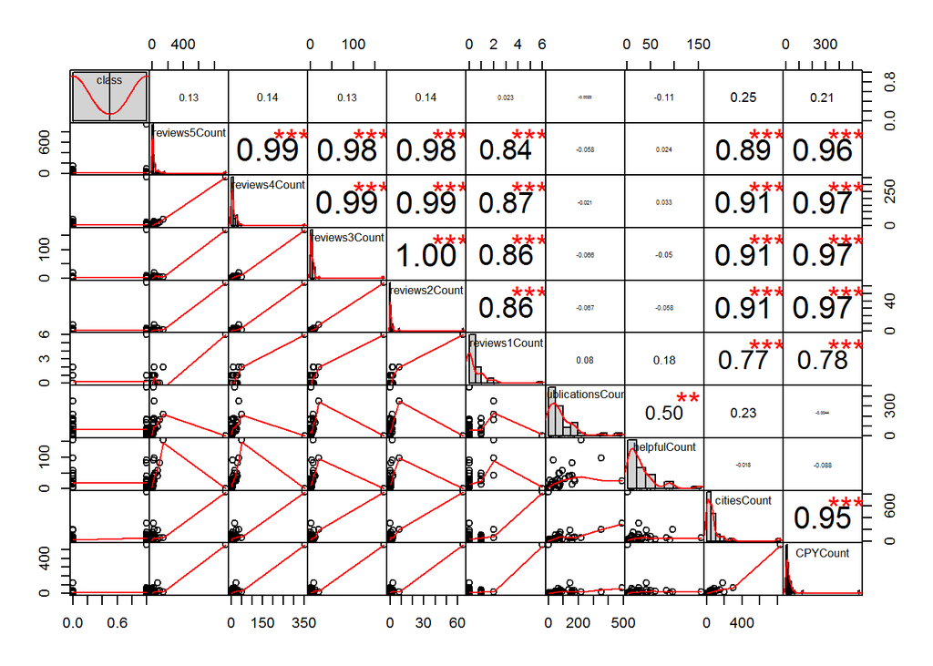

Из таблицы корреляции делаем вывод, что необходимо нормировать числовые значения в диапазон [0, 1].

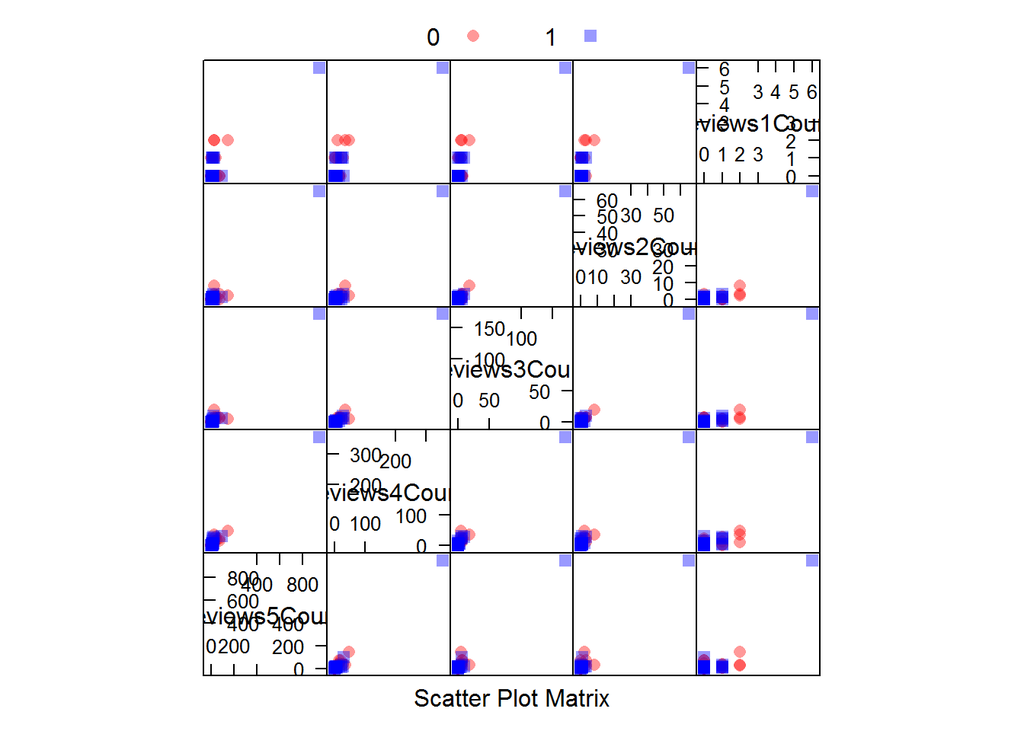

Из графика видим:

1. параметр reviews1Count полезен для классификации
2. большая часть точек сосредоточена в области низких значений, соответственно нормирование может улучшить избирательную способность остальных параметров (“reviews(2-5)Count”“)

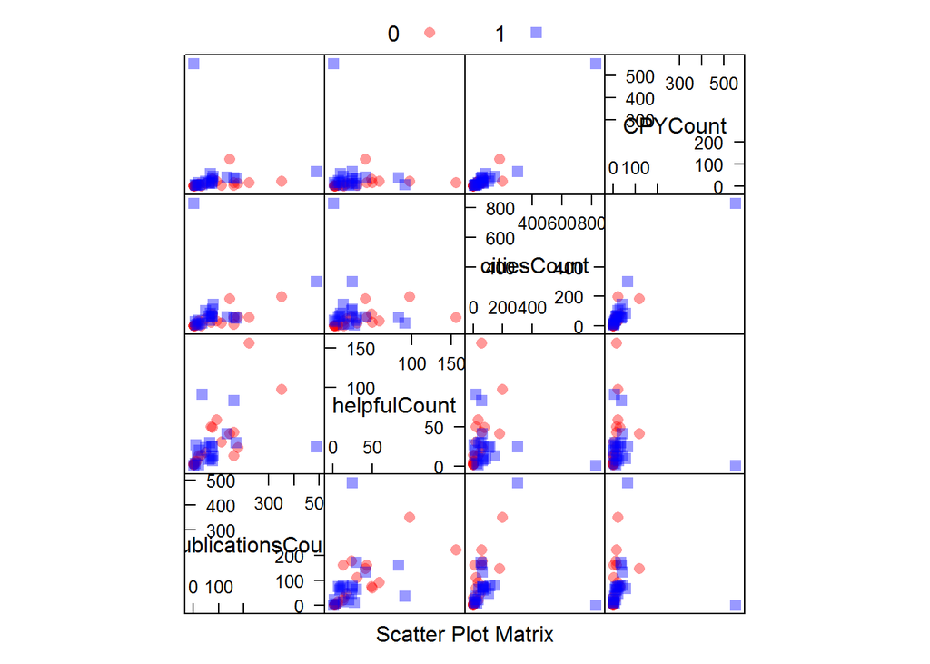

Из графика видим:

- Интересующие нас категории (0-не инетресен, 1 - интересен) сильно перемешаны. Визуально выделить эти классы пользователей на основе представленных параметров нельзя.
- CPYCount имеет выброс. Необходимо нелинейное нормирование, которое “растянет середину”. Используем предобразование Yeo-Johnson, которое делает данные близкими к нормальному (гауссовому) распределению, затем приведем данные к диапазону [0, 1]
- Остальные параметры следует отнормировать линейно в диапазон [0, 1].

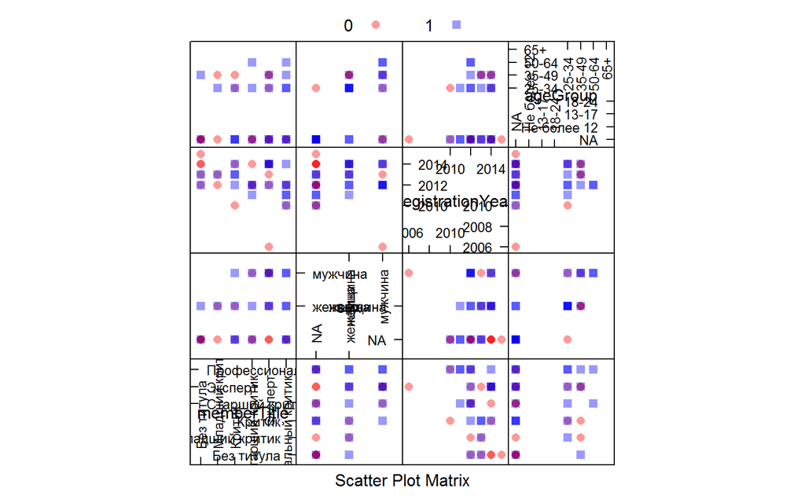

```
##
##    <NA> женщина мужчина
##      19      11      10
```

Из графика видим:

- звание пользователя (memberTitle) - полезный параметр для разделения классов. Оставим его упорядоченным категориальным, хотя могли бы сделать числовым в диапазоне [0, 1].
- пол (sex) - Может иметь значение для нашей задачи. Плохо, что данный параметр имеет довольно большоей количество неопределенных значений. **Необходимо применить алгоритм предсказывания пола перед предсказыванием категории клиента “инетресен/не инетересен”.** Для начала используем алгоритм, реализованный в библиотеке caret (preProcess, method = (“knnImpute”, “bagImpute”)). Для улучшения качества работы всей классифицируещй цепи целесообразно применить методы определения пола на основе текстов отзывов, т.е. с использованием набора данных “MaldivesHotelReviews”.
- год регистрации (registrationYear) - теоретически не должен влиять на решаемую задачу, однако график показывает, что влияние есть. Нормируем этот параметр в диапазон [0, 1].
- возрастная группа (ageGroup) - имеет определенную корреляцию с категорией (классом) пользователя. Плохо, что содержит большое количество неопределенных значений, что в обучающей выборке отсутствуют данные для групп (менее 12 лет“,”13-17 лет“,”18-24“,”65+“). Предполагаю, что для качественного предсказания возрастной группы понадобится заметно больше обучающих данных и, даже если мы из получим, не факт, что результат предсказания будет достаточно точным. Планирую попробовать варианты:
  - заполнять отсутствующие значения “дешевым” методом “knnImpute”.
  - сделать поле числовым в диапазоне [0, 1], подумать над методом заполнения (“medianImpute”, линейная регрессия, …).
  - ввести новую категорию “возраст не известен”. Тогда этот параметр не будет “мешать” прогнозированию, если он ен известен. Возможно, это даст такой же результат, как и предыдущий вариант (медиана).

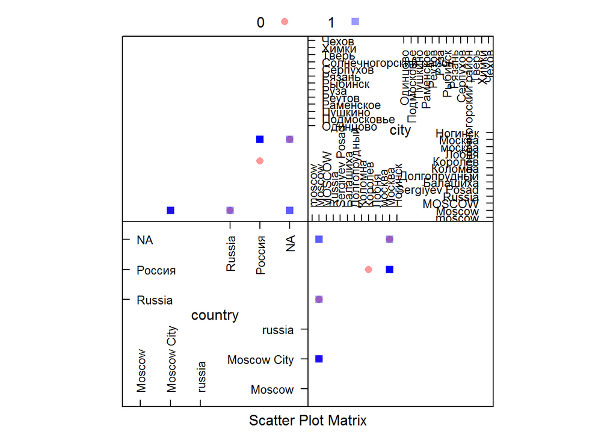

Несмотря на то, что интуитивно кажется, что представленные на графике параметры Страна (country) и Город (city) не должны иметь значения, т.к. в рассматриваемом наборе данных пользователи уже отобраны по геопризнаку “Москва и окрестности”, график показывает, что эти параме ры могут быть полезны для классификации. Преобразуем их в категориальные (бинарные) переменные.

## Подготовка параметров набора данных

*) Возможно другое решение.

**Примечание:** Подготовка данных для всех пользователей, оставивших отзывы об отелях на Мальдивах, приведена в membersFeatures.Rmd.

## Разведка нормализованных данных

Посмотрим заголовок данных после нормализации, выведем первые 40 параметров (столбцов).

```
##                                uid    memberTitle            ageGroup
## 1 813EFCF9A589AA6F946F82BB5FF9619E        Эксперт Возраст не известен
## 2 1AC301553A4995D3CE2DE923E752969F     Без титула Возраст не известен
## 3 F72DFA205249975A68620F8234A451AF Старший критик Возраст не известен
## 4 F9C407B9C042CA6EF7F7818EC1027D97     Без титула Возраст не известен
## 5 BA46856688BB68CED76F5DA164B3EEFA Старший критик Возраст не известен
## 6 4D29748A00F0BAABF599B1DF63D7598D        Эксперт               35-49
##               sex   city country class reviews5Count reviews4Count
## 1         мужчина Москва  Россия     1     1.0000000     1.0000000
## 2 Пол не известен Москва  Россия     0     0.0000000     0.0000000
## 3 Пол не известен Москва  Россия     0     0.2098133     0.5594782
## 4 Пол не известен Москва  Россия  <NA>     0.0000000     0.0000000
## 5 Пол не известен Москва  Россия     1     0.4783569     0.3602122
## 6         мужчина Москва  Россия     1     0.4974828     0.7884289
##   reviews3Count reviews2Count reviews1Count publicationsCount helpfulCount
```

[output cut: 55 more lines]

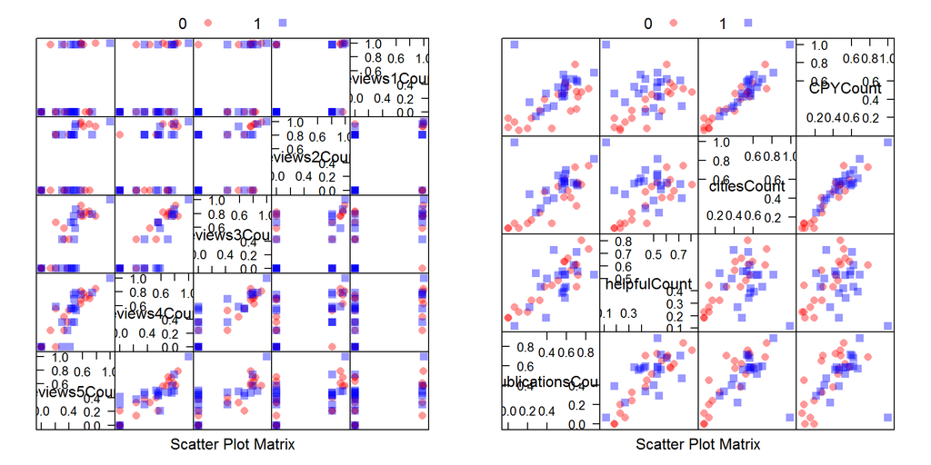

Из графиков видим, что параметры *Count стали более информативными, однако визуально выделить категории пользователей не просто.

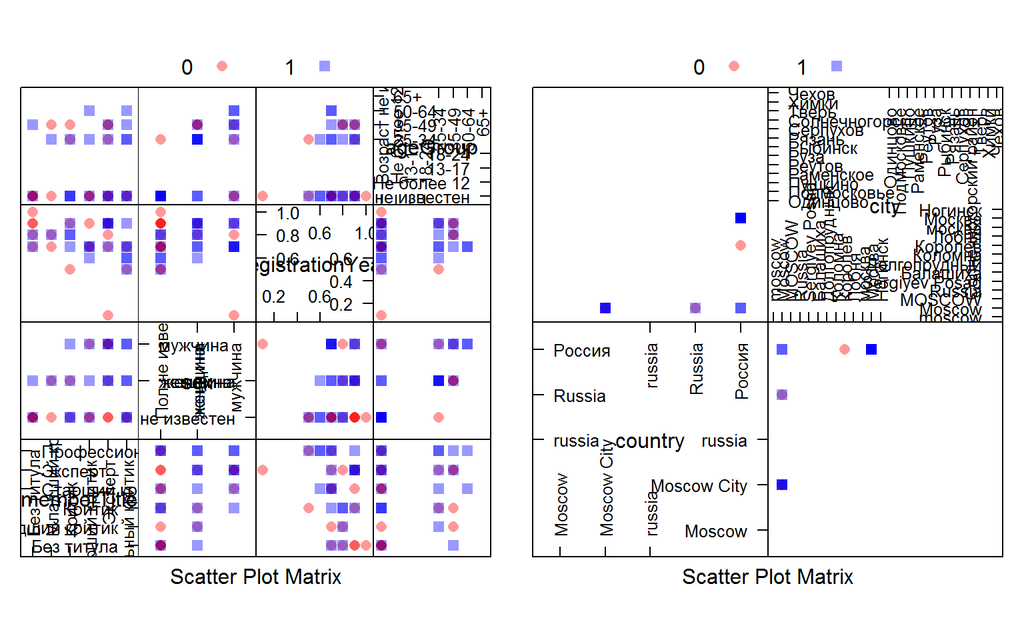